# 横縞はなぜ太って見えるのか？

高橋康介

2019/5/22

```r
# パッケージ読み込み
library(plyr)
library(ggplot2)
library(reshape2)
library(knitr)
```

## 概要

- 横縞は太って見えるらしい。
- しかし、ヘルムホルツ錯視的には、横縞のほうが「細く」見えるはず。
- 横縞は、視覚的な太さというより、「重さ」感を増幅させているのではないか（〇〇省風）。
- 太さの判断だけでなく、重さの判断も検討するべきではないか。

### 実験概要

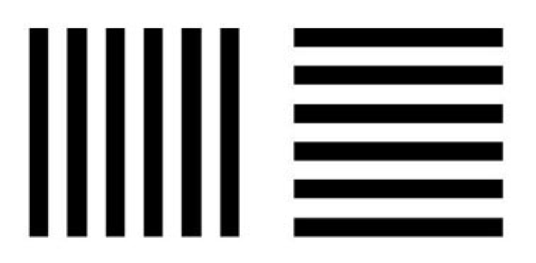

- 縦縞と横縞を左右に提示
- 課題は2種類（ブロックデザイン）
  - 「重さ」判断 vs. 「横幅」判断
- 恒常法
  - 縦縞は正方形で固定。
  - 横縞は幅92%から108%まで7段階
- 反応は、左右どちらが「重く見えたか」「幅が広く見えたか」

## データの読み込みと確認

```r
## データ読み込み
d = ldply(dir("data", "csv$", full.names = TRUE), read.csv)

## データの要約など確認
names(d) # 列名
```

```
##  [1] "Task"                 "Run"                  "Standard"             "Border"               "WH"                   "blocks.thisRepN"      "blocks.thisTrialN"    "blocks.thisN"         "blocks.thisIndex"     "trials.thisRepN"      "trials.thisTrialN"    "trials.thisN"         "trials.thisInde…
```

```r
# kable(head(d)) # 先頭数行
dim(d) # サイズ
```

```
## [1] 6144   23
```

```r
table(d$participant) # 被験者ごとの行数
```

```
##
##   1   2   3   4   5   6   7   8   9  10  11  12  13  14  15  16  17  18  19  20  21  22  23  24
## 256 256 256 256 256 256 256 256 256 256 256 256 256 256 256 256 256 256 256 256 256 256 256 256
```

```r
unique(table(d$participant)) # 全部同じであることを確認
```

```
## [1] 256
```

```r
np = length(table(d$participant)) # 被験者数
```

被験者数: 24

### データについてのメモ書き

- rTask: 1=大きさ 2=重さ
- Run: 0なら練習
- Standard: 縦縞刺激の位置（-1: 左, +1: 右）
- WH: 横縞の縦横比（マイナスなら縦長、プラスなら横長）
- key_resp_answer.keys: 反応キー(’f’なら左、’j’なら右)
- key_resp_answer.rt: 反応時間
- participant: 被験者ID

## 下処理

- 不要な行・列を削除する
  - Runが0の行は削除。
  - key_resp_answer.rtが`NA`の行は削除。
  - 必要な列を抽出

```r
# 必要な行だけ抽出
dat = d
dat = subset(dat, Run == 1 & !is.na(key_resp_answer.rt))
dat = subset(dat, select = c(rTask, Standard, WH, key_resp_answer.keys, key_resp_answer.rt, participant))
# 確認
kable(head(dat))
```

|  | rTask | Standard | WH | key_resp_answer.keys | key_resp_answer.rt | participant |
| --- | --- | --- | --- | --- | --- | --- |
| 16 | 2 | 1 | 0.050 | f | 1.4382010 | 1 |
| 17 | 2 | -1 | 0.050 | j | 1.2867029 | 1 |
| 18 | 2 | 1 | 0.075 | f | 1.1051371 | 1 |
| 19 | 2 | -1 | 0.025 | j | 0.7384689 | 1 |
| 20 | 2 | -1 | 0.000 | f | 1.2549250 | 1 |
| 21 | 2 | -1 | -0.075 | f | 1.1885650 | 1 |

```r
table(dat$rTask, dat$participant) # 条件ごとの試行数、人数
```

```
##
##       1   2   3   4   5   6   7   8   9  10  11  12  13  14  15  16  17  18  19  20  21  22  23  24
##   1 112 112 112 112 112 112 112 112 112 112 112 112 112 112 112 112 112 112 112 112 112 112 112 112
##   2 112 112 112 112 112 112 112 112 112 112 112 112 112 112 112 112 112 112 112 112 112 112 112 112
```

```r
unique(table(dat$rTask, dat$participant)) # 全員一緒か？
```

```
## [1] 112
```

- 反応を左右から「横縞刺激を選択したか？」に:
  - YES: Standardが1でキーが’f’ またはStandardが-1でキーが’j’
  - NO: Standardが1でキーが’j’ またはStandardが-1でキーが’f’
- 課題のラベルと数値からテキストに

```r
dat$resp = ifelse(dat$key_resp_answer.keys=='f', -1, 1) # 反応を数値に
dat$ans = ifelse(dat$Standard == -dat$resp, 1, 0) #反応と横縞刺激の位置が一致してたら1、そうでなければ0
dat$rTask = factor(dat$rTask, labels = c("大きさ", "重さ")) # 課題のラベルづけ

# 確認
kable(head(dat))
```

|  | rTask | Standard | WH | key_resp_answer.keys | key_resp_answer.rt | participant | resp | ans |
| --- | --- | --- | --- | --- | --- | --- | --- | --- |
| 16 | 重さ | 1 | 0.050 | f | 1.4382010 | 1 | -1 | 1 |
| 17 | 重さ | -1 | 0.050 | j | 1.2867029 | 1 | 1 | 1 |
| 18 | 重さ | 1 | 0.075 | f | 1.1051371 | 1 | -1 | 1 |
| 19 | 重さ | -1 | 0.025 | j | 0.7384689 | 1 | 1 | 1 |
| 20 | 重さ | -1 | 0.000 | f | 1.2549250 | 1 | -1 | 0 |
| 21 | 重さ | -1 | -0.075 | f | 1.1885650 | 1 | -1 | 0 |

## 可視化

- とりあえず反応時間のヒストグラムをプロットしてみる
- 必要に応じて躊躇せず可視化！

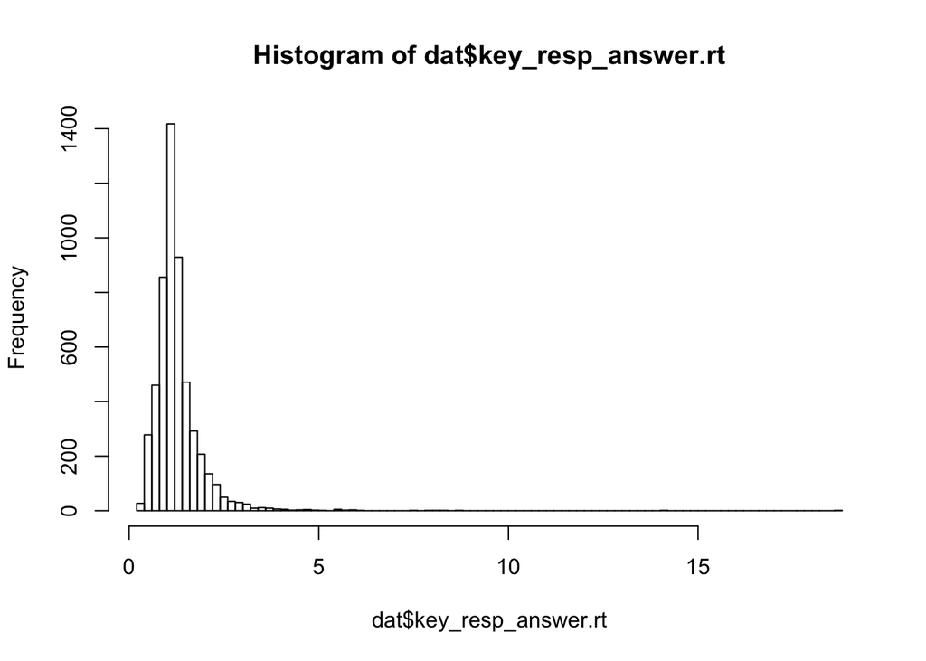

```r
hist(dat$key_resp_answer.rt, breaks = 100)
```

- 反応時間が長すぎる試行を除外するとか（チュートリアル用に乱暴なやりかたです。基準は実験前に決めておかないとNG）。

```r
dat2 = subset(dat, key_resp_answer.rt < 10)
# 長過ぎる試行の数、割合
c(nrow(dat)-nrow(dat2), (nrow(dat2)-nrow(dat))/nrow(dat))
```

```
## [1]  2.0000000000 -0.0003720238
```

## 集約

- 被験者 X タスク X WHごとに平均の横幅選択率を計算
  - 横幅選択=1、そうでない=0にコード化してあるので、単純に平均する

```r
dat.m1 = ddply(dat, .(participant, rTask, WH), summarise, ans = mean(ans))
# 確認
kable(head(dat.m1))
```

| participant | rTask | WH | ans |
| --- | --- | --- | --- |
| 1 | 大きさ | -0.075 | 0.1250 |
| 1 | 大きさ | -0.050 | 0.2500 |
| 1 | 大きさ | -0.025 | 0.5625 |
| 1 | 大きさ | 0.000 | 0.3125 |
| 1 | 大きさ | 0.025 | 0.6875 |
| 1 | 大きさ | 0.050 | 0.7500 |

```r
dim(dat.m1) # 被験者数ｘ２課題ｘ７レベルのはず
```

```
## [1] 336   4
```

```r
np*2*7
```

```
## [1] 336
```

## 可視化

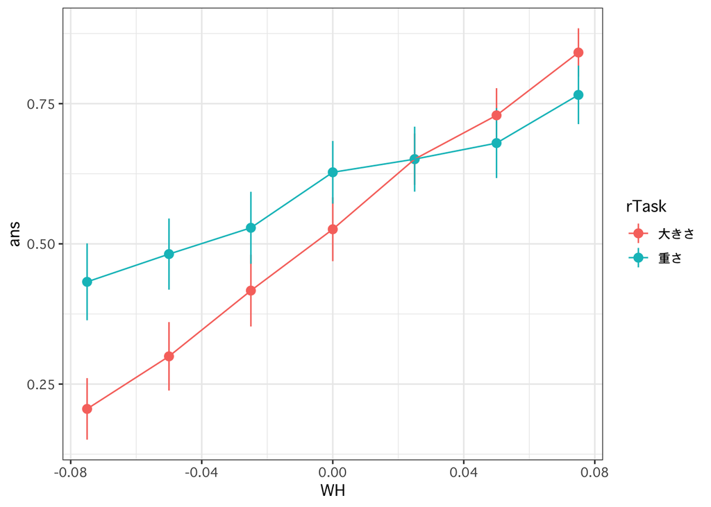

```r
library(ggplot2)
g  = ggplot(dat.m1, aes(WH, ans, colour = rTask, group = rTask)) +
  stat_summary(fun.data = mean_se) +
  stat_summary(fun.y = mean, geom = "line") +
  theme_bw(base_family = "Osaka") # Windowsの場合はフォントがないかも？
g
```

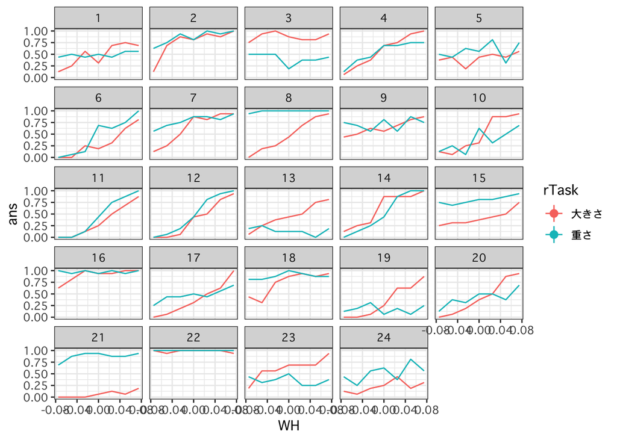

```r
g + facet_wrap(~participant)
```

## 統計

- ANOVA君 http://riseki.php.xdomain.jp/index.php?ANOVA%E5%90%9B を使ってみました。
- 井関先生、ありがとうございます！

```r
source('anovakun_482.txt')
anovakun(dat.m1, "sAB", long = TRUE)
```

```
##
## [ sAB-Type Design ]
##
## This output was generated by anovakun 4.8.2 under R version 3.5.3.
## It was executed on Wed May 22 17:24:57 2019.
##
##
## << DESCRIPTIVE STATISTICS >>
##
## --------------------------------------
##   rTask      WH   n    Mean    S.D.
## --------------------------------------
## 大きさ  -0.075  24  0.2057  0.2687
## 大きさ   -0.05  24  0.2995  0.2989
## 大きさ  -0.025  24  0.4167  0.3137
## 大きさ       0  24  0.5260  0.2788
## 大きさ   0.025  24  0.6510  0.2242
## 大きさ    0.05  24  0.7292  0.2372
## 大きさ   0.075  24  0.8411  0.2117
##  重さ  -0.075  24  0.4323  0.3358
##  重さ   -0.05  24  0.4818  0.3109
##  重さ  -0.025  24  0.5286  0.3144
##  重さ       0  24  0.6276  0.2737
##  重さ   0.025  24  0.6510  0.2837
##  重さ    0.05  24  0.6797  0.3058
##  重さ   0.075  24  0.7656  0.2555
## --------------------------------------
##
##
## << SPHERICITY INDICES >>
##
## == Mendoza's Multisample Sphericity Test and Epsilons ==
##
## ----------------------------------------------------------------------------
##     Effect  Lambda  approx.Chi  df      p         LB     GG     HF     CM
## ----------------------------------------------------------------------------
##     Global  0.0000    323.1748  90 0.0000 *** 0.0769 0.2530 0.3003 0.2938
##      rTask  1.0000     -0.0000   0            1.0000 1.0000 1.0000 1.0000
##         WH  0.0000    127.1844  20 0.0000 *** 0.1667 0.2602 0.2758 0.2698
## rTask x WH  0.0000     54.3881  20 0.0001 *** 0.1667 0.5009 0.5846 0.5719
```

[output cut: 174 more lines]

```
##    -0.075-0.05  -0.2474   3.3847  23  0.0026  0.0342    -0.075 < 0.05 *
##     0.05-0.075  -0.0859   3.0306  23  0.0059  0.0654     0.05 = 0.075
##    -0.05-0.025  -0.1693   2.9832  23  0.0066  0.0665    -0.05 = 0.025
##     -0.05-0.05  -0.1979   2.8801  23  0.0085  0.0761     -0.05 = 0.05
##   -0.025-0.025  -0.1224   2.4560  23  0.0220  0.1542   -0.025 = 0.025
##    -0.025-0.05  -0.1510   2.3661  23  0.0268  0.1874    -0.025 = 0.05
##       -0.025-0  -0.0990   2.3258  23  0.0292  0.1874       -0.025 = 0
##   -0.075--0.05  -0.0495   2.1628  23  0.0412  0.2060   -0.075 = -0.05
##   -0.05--0.025  -0.0469   2.0695  23  0.0499  0.2060   -0.05 = -0.025
##         0-0.05  -0.0521   1.2253  23  0.2329  0.6986         0 = 0.05
##     0.025-0.05  -0.0286   0.7939  23  0.4353  0.8707     0.025 = 0.05
##        0-0.025  -0.0234   0.5892  23  0.5615  0.8707        0 = 0.025
## --------------------------------------------------------------------------
##
## output is over --------------------///
```

## 結論

- 横縞が太って見えるのは、幅が広く見えるわけじゃなくて、「重そうに」見えるから。